```
      ** ML & NLP Meets Quantum: Pennylane Integration with Lambeq **

                   Speakers: aditya & Bayang & Sofii

                 **    Data Science Summit 2023 **
```

# Outline

- Quantum Machine Learning (QML) & Pennylane
- Quantum Natural Language Processing (QNLP)
- DisCoCat & DisCoPy
- Lambeq library
- QNLP Pipeline: Integration of Lambeq & Pennylane
- Outlook & Open Questions

# Quantum Machine Learning: QML

- **Exploring the interplay of ideas from quantum computing and machine learning**
- Quantum circuits can be used as machine learning models
- Growing interest in quantum machine learning on noisy intermediate-scale [NISQ] quantum devices

## Quantum and Classical ML

[figure not shown]

###### Source: Quantum Machine Learning: A Review and Case Studies https://www.mdpi.com/1099-4300/25/2/287

## Quantum and Classical ML

[figure not shown]

###### Source: Quantum Machine Learning: A Review and Case Studies https://www.mdpi.com/1099-4300/25/2/287

## Training

#### Quantum computers can be used and trained like neural networks

[figure not shown]

###### source: https://blog.paperspace.com/beginners-guide-to-quantum-machine-learning/

# Pennylane Library

- Cross-platform Python library for programming quantum computers
- Differentiable programming paradigm enables the execution and training of quantum programs on various backends (built-in automatic differentiation)
- PennyLane connects quantum computing with powerful machine learning frameworks like NumPy’s autograd, JAX, PyTorch, and TensorFlow, making them quantum-aware

###### For hands on please follow the tutorials https://pennylane.ai/qml/demos/

#### Pennylane

[figure not shown]

#### Component: QNodes

[figure not shown]

## Pennylane Example Code

[figure not shown]

# Quantum Natural Language Processing: QNLP

- *Cambridge Quantum* have leveraged mathematical principles to build a bridge between quantum theory and linguistic structures
- Language is “quantum native”
- Pioneering work by Bob Coecke and Aleks Kissinger
- Sentences as networks, not just a “bag of words”, where words interact in a particular fashion

## Distributed and Compositional Category Theory (DisCoCat)

### Natural Language is Quantum Native

[figure not shown]

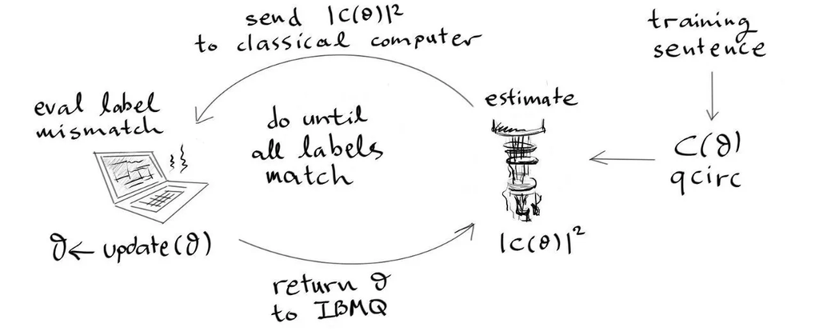

# DisCoPy

##### Python toolkit for computing with string diagrams

```
Organisation: https://discopy.org
Documentation: https://docs.discopy.org
Source code: https://github.com/discopy/discopy
Paper (for applied category theorists): https://doi.org/10.4204/EPTCS.333.13
Paper (for quantum computer scientists): https://arxiv.org/abs/2205.05190
```

## Lambeq

- Framework rooted in mathematical linguistics & Lambek Calculus for Quantum Entanglement."
- Features Lambeq: Semantic Composition & bridge the gap between linguistic structure and quantum information processing

[figure not shown]

###### source: https://cqcl.github.io/lambeq/

# QNLP Pipeline: Lambeq

[figure not shown]

# Further Developments & Open Questions

##### Importance of Quantum advantage: quantum algorithms outperform classical

##### Future work on reduction in reliability on large datasets and complicated models with numerous parameters

##### Quantum NLP implementation: scaling the context-free grammar (CFG) models and producing strong formal descriptions for other languages

### References

```
        More Details on the Pennylane's website https://pennylane.ai/qml/

   The Talk is uploaded on the github: https://github.com/adytiaa/dss_qnlp_talk/tree/master
```

[figure not shown]